# Clustering - exercises

```r
library(RColorBrewer)
library(factoextra)
library(mclust)
library(cluster)
```

## The data

Dataset: cancer cell line microarray data.

```r
# Load the data
load(file="data.RData")
load(file="labs.RData")
```

```r
dim(data)
```

```
## [1]   30 6830
```

The dataset contains 30 observations and 6830 variables (genes). $x_{i,j}$ is the entry of the matrix at line $i$ and column $j$ and it represents the gene $j$ expression in sample $i$.

The data look like this:

```r
data[1:4,1:6]
```

```
##              1          2          3          4         5           6
## V47 -0.2900000  0.0300000 -0.3100000  1.5000000 0.0050000 -0.54000000
## V53 -0.4299805 -0.3899805 -0.1799805  0.8600195 0.7850195  0.04001953
## V32  0.3200000  0.2800000  0.3600000 -1.8800000 0.4750000  0.11000000
## V56 -0.6200000 -0.1300000  0.2000000 -1.4100000 1.5850000  1.16000000
```

For our analysis we will consider the most variable genes and then we will normalize the data:

- Select the 50 most variable genes
- Scale the data by using the R function scale(). This function is used to scale the columns of a numeric matrix. In particular each entry $x_{i,j}$ of column $X_i$ is transformed in the following way: $x_{i,j}^{\text{scaled}}=\frac{x_{i,j} - \text{mean}(X_i)}{\text{sd}(X_i)}$

```r
# important to scale the data (each gene in relation to itself)
var=apply(data,2,function(x) var(x,na.rm = TRUE))
var=var[order(var,decreasing = TRUE)]
more.var=names(var)[1:50]
data.var=data[,more.var]
data.var=scale(data.var) # scale before applying clustering
# all genes should have the same effect on the clusters
# eg if one gene is always more expressed, in general, it would have an overly big impact
```

For every sample we also know its cancer type. This information is contained in the vector “labs”.

```r
labs
```

```
##  [1] "COLON"    "NSCLC"    "NSCLC"    "MELANOMA" "LEUKEMIA" "MELANOMA"
##  [7] "MELANOMA" "LEUKEMIA" "MELANOMA" "COLON"    "COLON"    "COLON"
## [13] "LEUKEMIA" "NSCLC"    "MELANOMA" "COLON"    "NSCLC"    "MELANOMA"
## [19] "COLON"    "NSCLC"    "NSCLC"    "MELANOMA" "MELANOMA" "LEUKEMIA"
## [25] "NSCLC"    "LEUKEMIA" "LEUKEMIA" "COLON"    "NSCLC"    "NSCLC"
```

In particular, there are 4 different types of cancer: COLON, LEUKEMIA, MELANOMA and NSCLC (Non-Small Cells Lung Cancer).  
We can see how many samples there are for each type by using the R function table().

```r
table(labs)
```

```
## labs
##    COLON LEUKEMIA MELANOMA    NSCLC
##        7        6        8        9
```

This information is our ground truth, we will consider it for evaluating and comparing different clusters algorithms.

## Distance matrix

In order to perform clustering on our data, we first need to compute a **distance matrix**. We can do that by using the function dist() (package “stats”). Note that the default distance measure is the euclidean. We can change it by specifying the method that we prefer (ex: “euclidean”, “maximum”, “manhattan”, “binary”, …).

```r
dist.matrix=dist(data.var)
as.matrix(dist.matrix)[1:5,1:5]
```

```
##           V47       V53       V32       V56      V37
## V47  0.000000  8.389515  8.983331 12.061693 10.70121
## V53  8.389515  0.000000  8.114688 11.373135 11.34025
## V32  8.983331  8.114688  0.000000  9.707319 10.01651
## V56 12.061693 11.373135  9.707319  0.000000 10.33451
## V37 10.701211 11.340254 10.016509 10.334508  0.00000
```

```r
# the variable names represent cell lines
```

We can visualize our distance matrix with a heatmap:

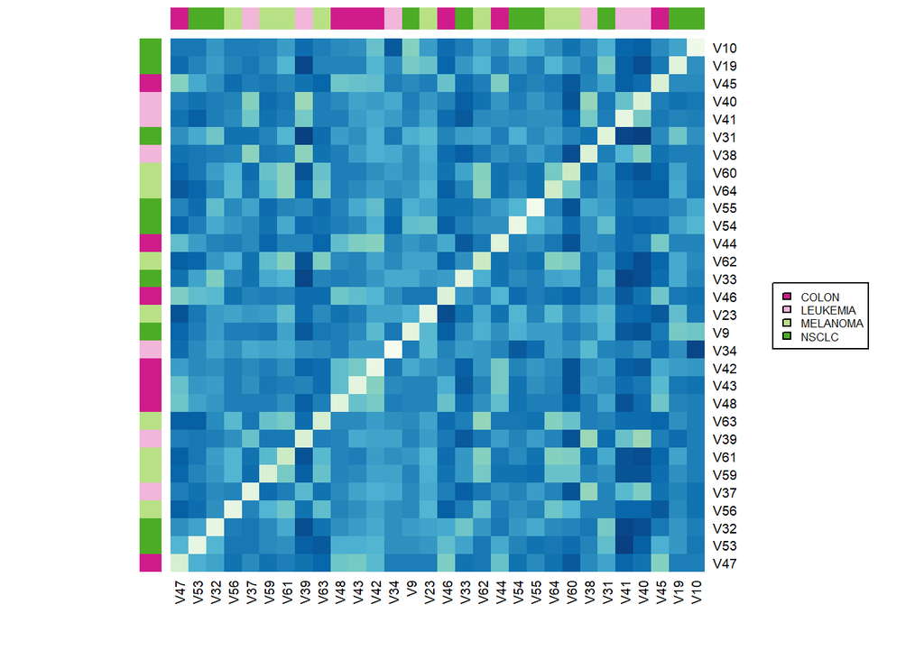

```r
# color palette
col <- colorRampPalette(brewer.pal(9, "GnBu"))(50)

# assign each cancer type a color
temp <- as.numeric(as.factor(labs))
colsamples <- brewer.pal(4, "PiYG")[temp]

heatmap(as.matrix(dist.matrix),Colv = NA, Rowv = NA,col=col,RowSideColors=colsamples,ColSideColors=colsamples)
legend(x="right",legend=c("COLON","LEUKEMIA","MELANOMA","NSCLC"),
     fill=brewer.pal(4, "PiYG"),cex=0.5)
```

## DBSCAN

The clustering algorithm DBSCAN can be run in R with the function dbscan() (package “dbscan”)

```r
library(dbscan)
```

*Remark*: DBSCAN requires two input parameters: **ε** and **minPts** (the desired minimum cluster size). Mean points: number of neighbours to be considered a core point(?) epsilon: max distance between 2 points for them to be considered neighbours One way for choosing ε is by using a k-distance graph (i.e. the distance to the k = minPts-1 nearest neighbor ordered from the largest to the smallest value). Good values of ε are where this plot shows an “elbow”. Notice that if ε is too small, a large part of the points will be considered as noise, whereas if ε is too big, the majority of objects will be clustered in the same unique cluster. a way to choose epsilon is to look at the data

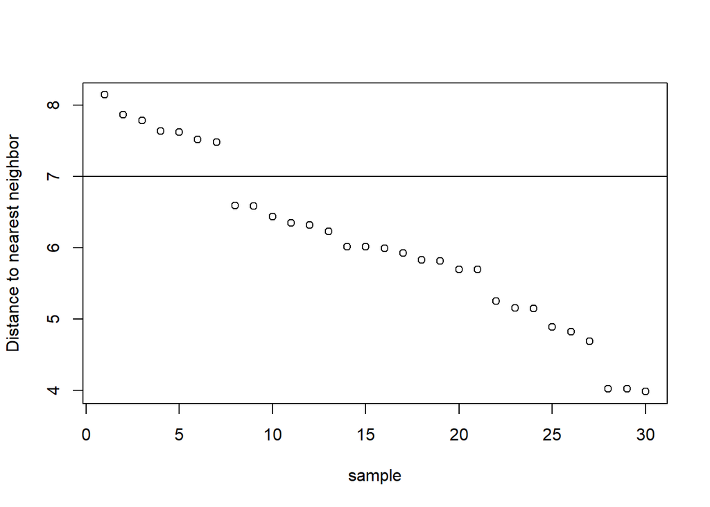

```r
nearest.dist=c()
dist.matrix=as.matrix(dist.matrix)
for(i in 1:ncol(dist.matrix)){
  temp=dist.matrix[,i]
  temp=temp[order(temp)]
  nearest.dist[i]=temp[3]
}
plot(1:length(nearest.dist),nearest.dist[order(nearest.dist,decreasing = TRUE)],xlab = "sample",ylab = "Distance to nearest neighbor")
abline(h=7)
```

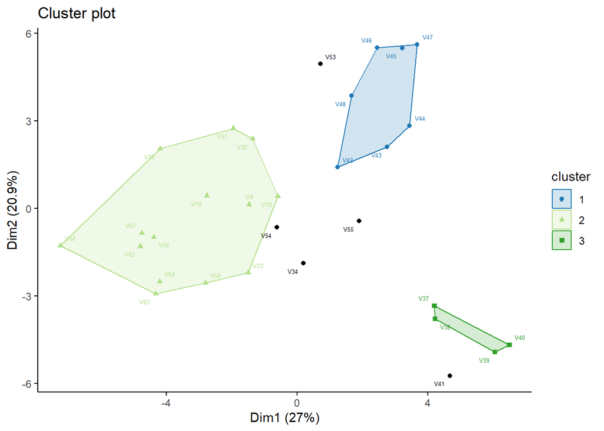

```r
db=dbscan(data.var, eps = 7, minPts = 3)
p=fviz_cluster(db, data = data.var, stand = FALSE,repel=TRUE, show.clust.cent = FALSE,palette = brewer.pal(6, "Paired")[-1], ggtheme = theme_classic(),labelsize=5)
p
```

Same plot but colored by true labels

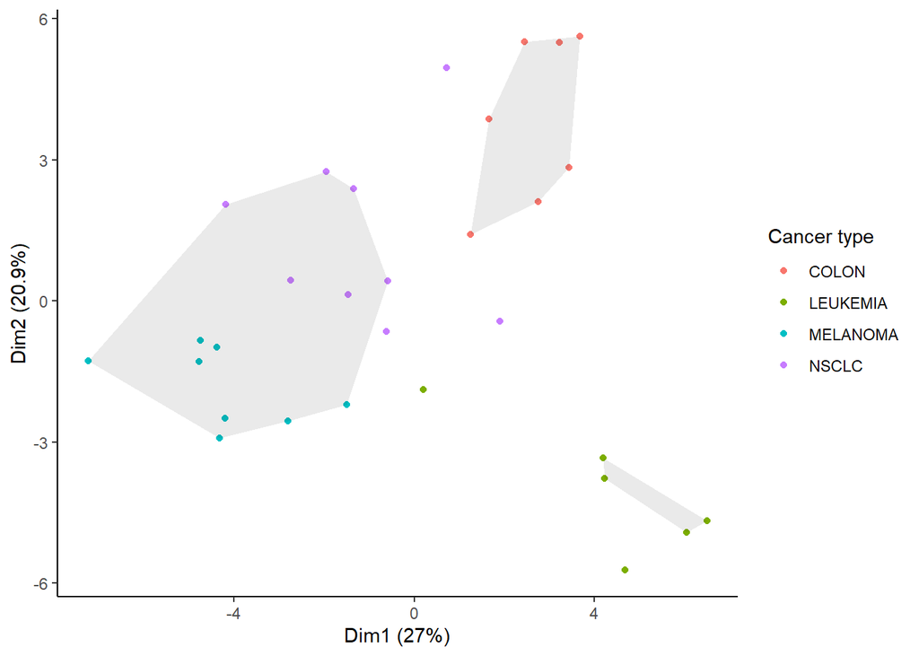

```r
for(i in 1:length(unique(p$data$cluster))){
  grp.i <- p$data[p$data$cluster == i, ][chull(p$data[p$data$cluster == i, c("x","y")]),]  # hull values for cluster i
  if(i==1) all_hulls=grp.i
  if(i>1) all_hulls=rbind(all_hulls,grp.i)
}

coord=as.data.frame(prcomp(data.var,scale. = TRUE)$x[,1:2])

ggplot(data = coord) +
  geom_point(aes(x = PC1, y = PC2, color = as.factor(labs))) +
  theme_classic()+ labs(x = p$labels$x, y = p$labels$y)+
  guides(color=guide_legend(title="Cancer type"))+
  geom_polygon(data = all_hulls, aes(x = x, y = y,group = as.factor(cluster)), alpha = 0.1)
```

```r
# a potential issue is that there is only 1 epsilon -> issue for groups with different densities.
```

**Silhouette Analysis**

```
##   cluster size ave.sil.width
## 0       0    5         -0.21
## 1       1    7          0.35
## 2       2   14          0.20
## 3       3    4          0.43
```

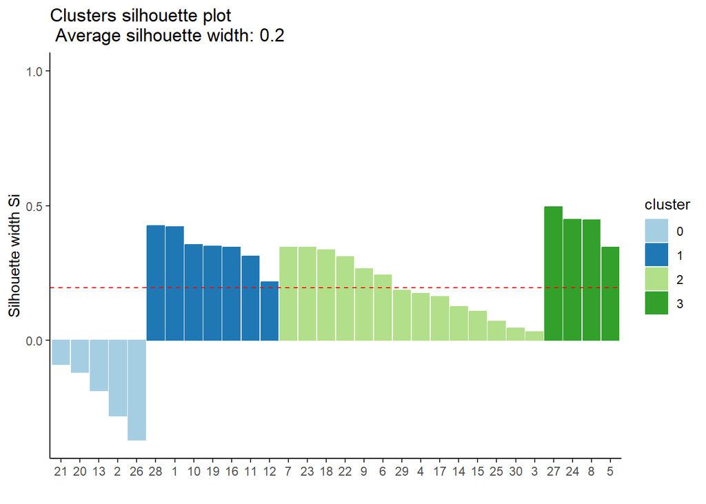

```r
sil <- silhouette(db$cluster,dist.matrix)

# the cluster 0 with negative values are the noise points
# -> here they are considered as the same cluster
# so this eg can be used to tell how many points are noise points

# another line of code where noise points are removed
fviz_silhouette(sil,palette = brewer.pal(length(unique(db$cluster)), "Paired")) + theme_classic()
```

**Adjusted Rand Index**

Since we know the true classification of the cell lines, we can compare the result of clustering to the ground truth. We compute the Adjusted Rand Index (ARI) using the R function adjustedRandIndex() contained in package “mclust”.

```r
adjustedRandIndex(labs,db$cluster)
```

```
## [1] 0.5270454
```

```r
# can also do it without the 0 cluster points
```

## Gaussian Mixture Models (GMM)

We now perform clustering using GMM, using the function Mclust() (package “mclust”). The parameter G indicates the number of mixture components (default is G=1:9)

```r
gmm <- Mclust(data.var)
summary(gmm) # input needed is the matrix of data
```

```
## ----------------------------------------------------
## Gaussian finite mixture model fitted by EM algorithm
## ----------------------------------------------------
##
## Mclust VEI (diagonal, equal shape) model with 4 components:
##
##  log-likelihood  n  df       BIC       ICL
##       -1476.774 30 256 -3824.254 -3824.254
##
## Clustering table:
##  1  2  3  4
##  7 11  7  5
```

The number of mixing components and the covariance parametrization are selected using the Bayesian Information Criterion (BIC). BIC is a penalised (penalty for the number of estimated parameters) form of the log likelihood. We want to maximize it.

```r
summary(gmm$BIC)
```

```
## Best BIC values:
##              VEI,4       VII,4       VEI,5
## BIC      -3824.254 -3842.40146 -3872.05177
## BIC diff     0.000   -18.14763   -47.79793
```

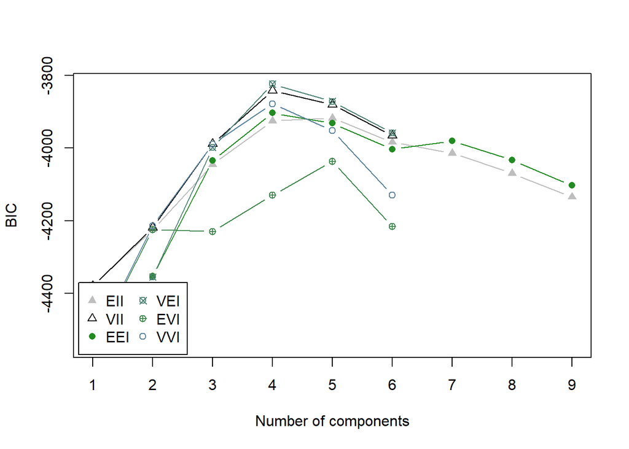

```r
plot(gmm, what = "BIC", legendArgs = list(x = "bottomleft"))
```

```r
# try many different models with different parameters for the gaussians,
# select the one with the highest log likelihood.
```

The possible models refer to different geometric characteristics of the models (volume, shape, orientation of the covariances across groups).

[figure not shown]

**Visualization**

In order to visualize the data we want to project our data in a suitable 2-dim space. We can do that using the function MclustDR(). The directions that mostly separate the estimated clusters are recovered using the default value 1

```r
drgmm=MclustDR(gmm,lambda = 0.998) # altering this param - 1 would be most separation
# drgmm=MclustDR(gmm,lambda = 1)
```

Contour plot of estimated mixture densities

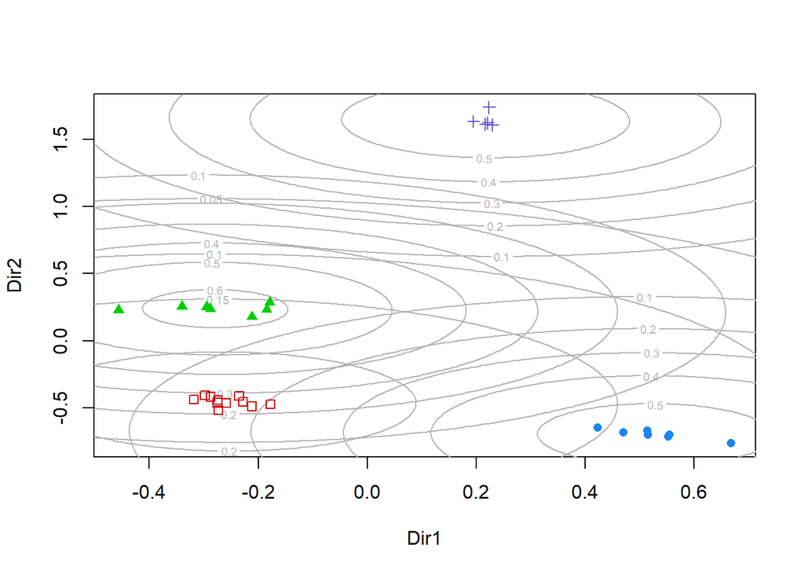

```r
plot(drgmm,what="contour",dimens = c(1,2))
```

Uncertainty boundaries (the uncertainty is shown using a greyscale with darker regions indicating higher uncertainty)

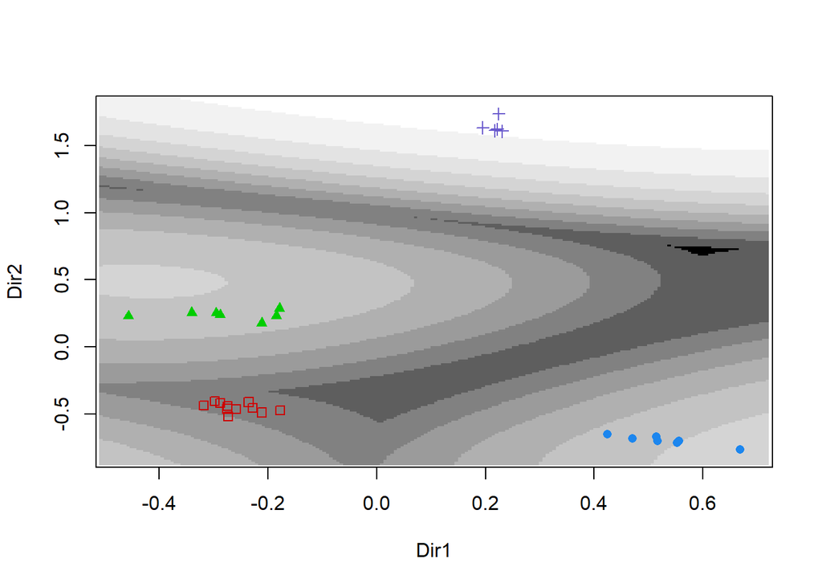

```r
plot(drgmm,what="boundaries")
```

Same plot colored by true cell type.

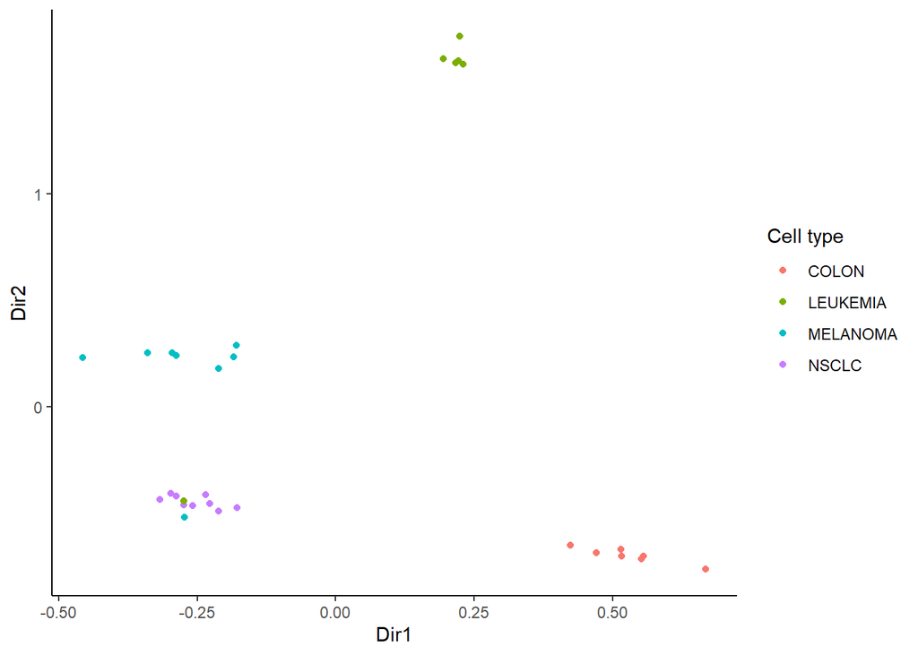

```r
ggplot(data = as.data.frame(drgmm$dir)) +
  geom_point(aes(x = Dir1, y = Dir2, color = as.factor(labs))) +
  theme_classic()+ labs(x = "Dir1", y = "Dir2")+
  guides(color=guide_legend(title="Cell type"))
```

**Silhouette analysis**

```
##   cluster size ave.sil.width
## 1       1    7          0.33
## 2       2   11          0.03
## 3       3    7          0.39
## 4       4    5          0.41
```

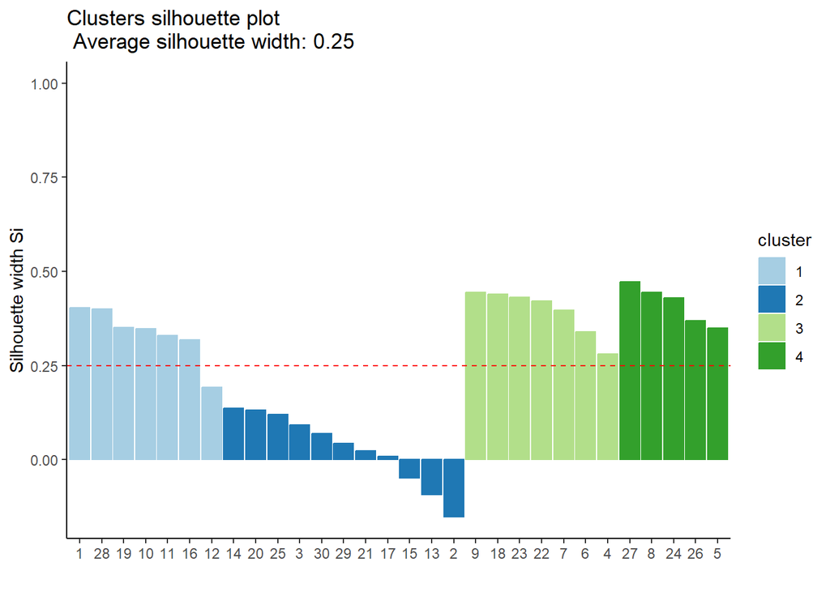

```r
sil <- silhouette(gmm$classification,dist.matrix)
fviz_silhouette(sil,palette = brewer.pal(length(unique(gmm$classification)), "Paired")) + theme_classic()
```

**Adjusted Rand Index**

```r
adjustedRandIndex(labs,gmm$classification)
```

```
## [1] 0.8035545
```

## Leiden

```r
library(igraph)
```

In order to perform clustering with Leiden algorithm we first need to represent the data with a graph. In particular, starting from the distance matrix we want to construct a graph. Each node is an observation and the edges will link the most similar observations.

How to construct an **adjacency matrix**? For example we can consider the 5-nearest neighbors.

```r
n=nrow(data.var)
adj.mat=matrix(0,nrow = n,ncol=n)
colnames(adj.mat)=rownames(as.matrix(dist.matrix))
rownames(adj.mat)=rownames(as.matrix(dist.matrix))
for(i in 1:ncol(adj.mat)){
  temp=as.matrix(dist.matrix)[i,]
  temp=temp[order(temp)]
  k.nearest=names(temp)[2:6]
  adj.mat[i,which(colnames(adj.mat)%in%k.nearest)]=1
  adj.mat[which(colnames(adj.mat)%in%k.nearest),i]=1
}
colnames(adj.mat)=rownames(data.var)
rownames(adj.mat)=rownames(data.var)

adj.mat[1:5,1:5]
```

```
##     V47 V53 V32 V56 V37
## V47   0   1   0   0   0
## V53   1   0   1   0   0
## V32   0   1   0   0   0
## V56   0   0   0   0   0
## V37   0   0   0   0   0
```

Next, we create a graph from the adjacency matrix.

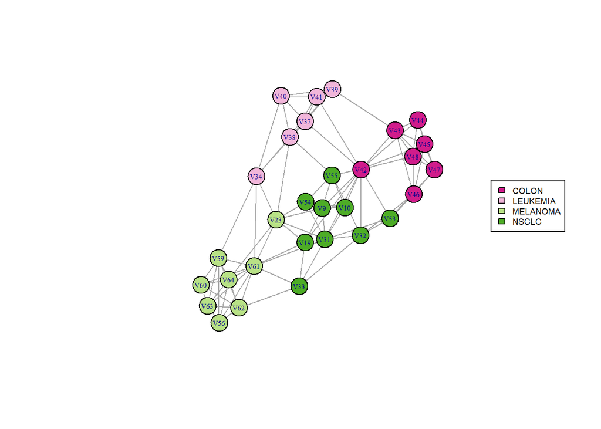

```r
graph <- graph_from_adjacency_matrix(adj.mat, mode = "undirected")
set.seed(123)
plot(graph, vertex.color = colsamples,vertex.label.cex=0.5)
legend(x="right",legend=c("COLON","LEUKEMIA","MELANOMA","NSCLC"),
     fill=brewer.pal(4, "PiYG"),cex=0.6)
```

We now can perform Leiden clustering.

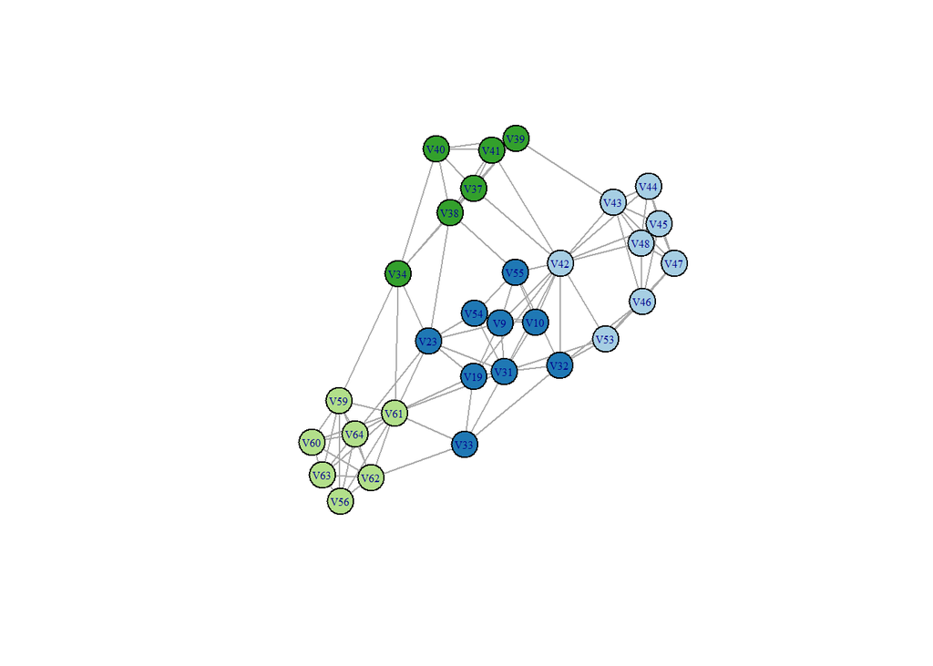

```r
leiden.cl=cluster_leiden(graph, objective_function = "modularity")

colcluster= brewer.pal(leiden.cl$nb_clusters, "Paired")[leiden.cl$membership]
set.seed(123)
plot(graph, vertex.color = colcluster,vertex.label.cex=0.5)
```

*Remark*: Louvain cluster can be done similarly by using the function cluster_louvain(). (Type “?cluster_louvain” for more details).

```
##   cluster size ave.sil.width
## 1       1    8          0.29
## 2       2    9          0.10
## 3       3    7          0.38
## 4       4    6          0.31
```

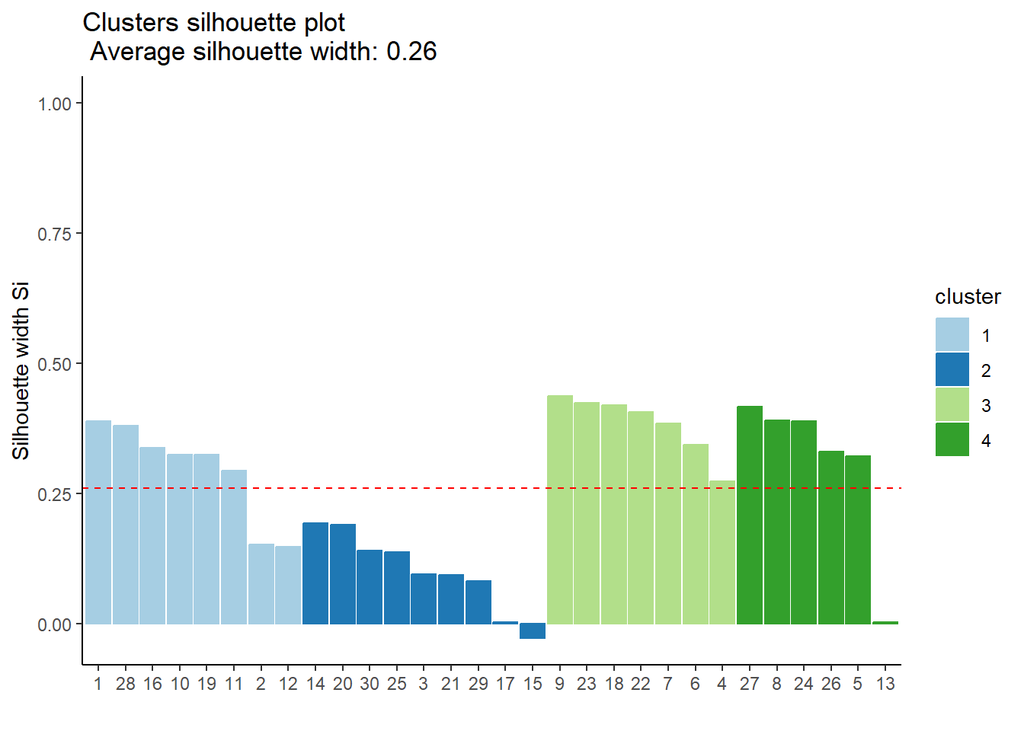

```r
sil <- silhouette(leiden.cl$membership,dist.matrix)
fviz_silhouette(sil,palette = brewer.pal(leiden.cl$nb_clusters, "Paired")) + theme_classic()
```

**Adjusted Rand Index**

```r
adjustedRandIndex(labs,leiden.cl$membership)
```

```
## [1] 0.8052239
```

## Compare the various clustering methods using the Adjusted Rand Index

Which method performs better?

```r
# Summary table for ARI
summ.ARI=matrix(NA,ncol = 2,nrow = 3)
colnames(summ.ARI)=c("Clustering method","ARI")
summ.ARI[,1]=c("DBSCAN","GMM","Leiden")
summ.ARI[1,2]=round(adjustedRandIndex(db$cluster, labs),3)
summ.ARI[2,2]=round(adjustedRandIndex(gmm$classification,labs),3)
summ.ARI[3,2]=round(adjustedRandIndex(leiden.cl$membership, labs),3)

knitr::kable(summ.ARI)
```

| Clustering method | ARI |
| --- | --- |
| DBSCAN | 0.527 |
| GMM | 0.804 |
| Leiden | 0.805 |